# Tilastollinen Oppimisen Jatkokurssi Round 4

#### (i)

*Comment on your results.* Linear logistic regression wasn’t all that good. Linear logistic regression on quadratic predictors worked well. Linear SVM was really bad. Non-linear SVM with quadratic kernel of degree 2 performed well, with some missclassifications on the decision boundary (probably due to the cost parameter).

We can try with the cost parameter set high enough.

```r
fit.svmnon = svm(x = as.matrix(subset(train, select=c(x1, x2))), y = as.factor(train$y), kernel = "polynomial", cost = 1000000, gamma=1, coef0 = 1, degree = 2)
fit.svmnon.pred = predict(fit.svmnon, data = train, type = "response")
train$pred = 1 * (as.numeric(fit.svmnon.pred) - 1)
plot(x = train$x1[train$pred == 1], y = train$x2[train$pred == 1], type = "p", col = "red", xlim = c(-0.5, 0.5), ylim = c(-0.5, 0.5))
points(x = train$x1[train$pred == 0], y = train$x2[train$pred == 0], col = "blue")
```

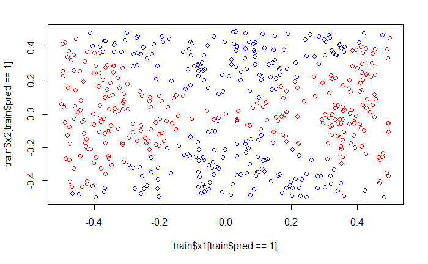

This worked since a higher cost parameter approaches the maximum margin classifier (as opposed to the soft margin calssifier).

## Exercise 4

*ISLR 9.7: In this problem, you will use support vector approaches in order to predict whether a given car gets high or low gas mileage based on the Auto data set.*

#### (a)

```r
library(ISLR)
set.seed(92)
train = model.matrix(~., subset(Auto, select = c(-mpg, -name)))[, 2:8]
cutoff = median(Auto$mpg)
y = as.factor(1 * (Auto$mpg > cutoff))
```

#### (b)

*Fit a support vector classifier to the data with various values of cost, in order to predict whether a car gets high or low gas mileage. Report the cross-validation errors associated with different values of this parameter. Comment on your results.*

```r
set.seed(92)
gridlen = 50
grid = 10^seq(from = -2, to = 2, length.out = gridlen)
folds = sample(cut(seq(1, 392), breaks = 10, labels = FALSE), 392)
meanmissclass = vector(mode = "double", length = gridlen)
for (i in 1:gridlen) {
  missclass = vector(mode = "double", length = 10)
  for (j in 1:10) {
    cvtestindex = which(folds == j, arr.ind = TRUE)
    cvtestx = train[cvtestindex, ]
    cvtesty = y[cvtestindex]
    cvtraix = train[-cvtestindex, ]
    cvtraiy = y[-cvtestindex]
    tmpfit  = svm(x = cvtraix, y = cvtraiy, kernel = "linear", cost = grid[i])
    tmppred = predict(tmpfit, newdata = cvtestx, type = "response")
    conf = table(tmppred, cvtesty)
    missclass[j] = (conf[1, 2] + conf[2, 1])/sum(conf)
  }
  meanmissclass[i] = mean(missclass)
}
plot(x = log10(grid), y = meanmissclass)
```

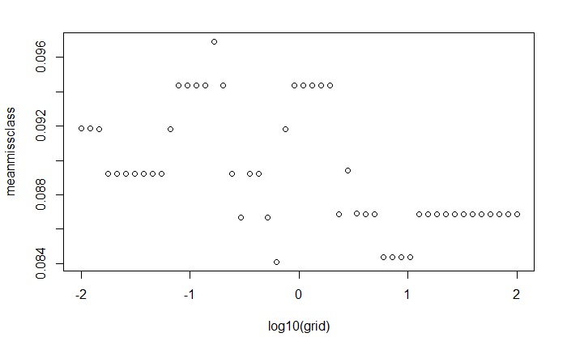

Disregarding the single point with low misslcassification rate near 0, it seems like log10(cost) should be around 1 or a little lower, meaning that the cost should be around 10 or a little lower. This gives a misscalssification rate around 0.0845.

#### (c)

*Now repeat (b), this time using SVMs with radial and polynomial basis kernels, with different values of gamma and degree and cost. Comment on your results.*

```r
set.seed(92)
train = scale(train)
gridlen = 10
gridcost = 10^seq(from = -2, to = 2, length.out = gridlen)
gridgamma = 10^seq(from = -2, to = 2, length.out = gridlen)
griddegree = seq(from = 2, to = gridlen, by = 1)
folds = sample(cut(seq(1, 392), breaks = 10, labels = FALSE), 392)
missclass = array(0, c(10, gridlen, gridlen, gridlen))
for (fold in 1:10) {
  cvtestindex = which(folds == fold, arr.ind = TRUE)
  cvtestx = train[cvtestindex, ]
  cvtesty = y[cvtestindex]
  cvtraix = train[-cvtestindex, ]
  cvtraiy = y[-cvtestindex]
  for (cost in 1:gridlen) {
    for (gamma in 1:gridlen) {
      tmpfit = svm(x = cvtraix, y = cvtraiy, kernel = "radial",
                   cost = gridcost[cost], gamma = gridgamma[gamma])
      tmppred = predict(tmpfit, newdata = cvtestx, type = "response")
      conf = table(tmppred, cvtesty)
      missclass[fold, cost, gamma, 1] = (conf[1, 2] + conf[2, 1])/sum(conf)
      for (deg in 2:gridlen) {
        tmpfit = svm(x = cvtraix, y = cvtraiy, kernel = "polynomial",
                     cost = gridcost[cost], gamma = gridgamma[gamma],
                     coef0 = 1, degree = griddegree[deg-1])
        tmppred = predict(tmpfit, newdata = cvtestx, type = "response")
        conf = table(tmppred, cvtesty)
        missclass[fold, cost, gamma, deg] = (conf[1, 2] + conf[2, 1])/sum(conf)
      }
    }
  }
}
```

[output not shown]

[output cut: 232 more lines]

[output not shown]

```r
meanmissclass = apply(missclass, c(2,3,4), mean)
persp(log10(gridcost), log10(gridgamma), meanmissclass[, , 1], phi = 10, theta = 35)
```

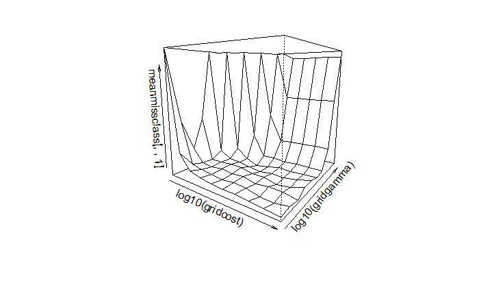

For the radial basis kernel it seems like the missclassification error rate decreases with cost and increases with gamma

```r
persp(log10(gridcost), log10(gridgamma), meanmissclass[, , 2], phi = 10, theta = 35)
```

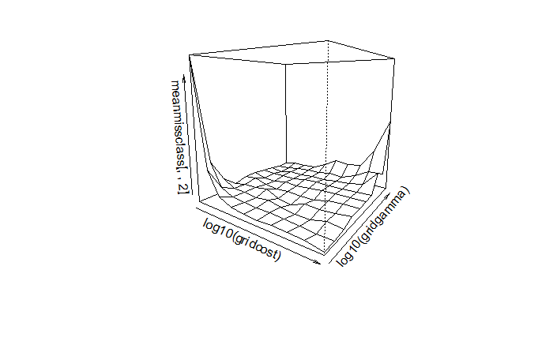

For the polynomial kernel with degree 2 there seems to be some kind of saddle-point phenomenon.

```r
persp(log10(gridcost), log10(gridgamma), meanmissclass[, , 10], phi = 10, theta = 35)
```

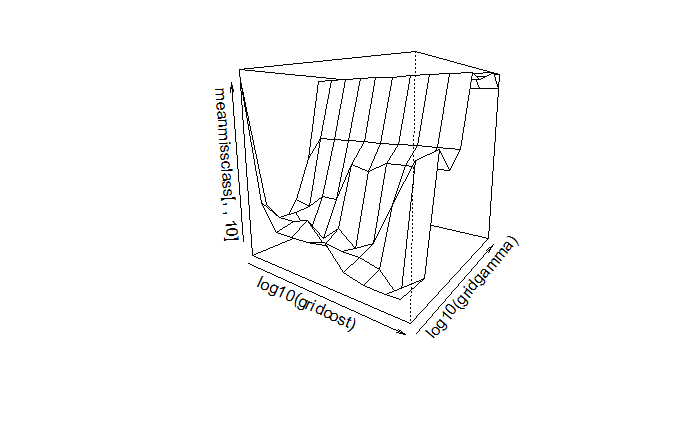

For the polynomial kernel with degree 10 the missclassification rate looks like a valley.

```r
persp(log10(gridcost), log10(gridgamma), meanmissclass[, , 5], phi = 10, theta = 35)
```

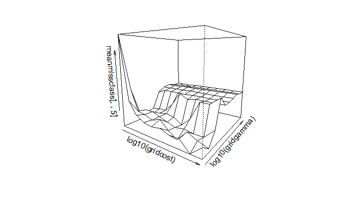

For the polynomial kernel with degree 5 the missclassification rate still looks like a valley but for high gamma-values there seems to be no change in missclassification rate when the cost changes.

```r
meanmissclass[which.min(meanmissclass)]; gridcost[5]; gridgamma[6]
```

```
[1] 0.06384615
[1] 0.5994843
[1] 1.668101
```

The lowest missclassification error seems to be cost ~ 0.6 and gamma ~ 1.7 with the radial basis kernel.

```r
meanmissclass[which.min(meanmissclass[,,-1])]; gridcost[9]; gridgamma[2]
```

```
[1] 0.07647436
[1] 35.93814
[1] 0.02782559
```

For the polynomial kernels the best hyperparameters were cost ~ 36, gamma ~ 0.028 and degree = 9.

#### (d)

*Make some plots to back up your assertions in (b) and (c).*

Not sure what plots they want me to make other than the ones I already made…

## Exercise 5

*ISLR 9.8: This problem involves the OJ data set which is part of the ISLR package.*

#### (a)

*Create a training set containing a random sample of 800 observations, and a test set containing the remaining observations.*

```r
set.seed(92)
ts = sample(seq(1:dim(OJ)[1]), 800)
traix = subset(OJ[ts, ], select=-Purchase)
testx = subset(OJ[-ts, ], select=-Purchase)
traix = model.matrix(~., traix)[, -1]
testx = model.matrix(~., testx)[, -1]
traiy = OJ$Purchase[ts]
testy = OJ$Purchase[-ts]
```

#### (b)

*Fit a support vector classifier to the training data using cost=0.01, with Purchase as the response and the other variables as predictors. Use the summary() function to produce summary statistics, and describe the results obtained.*

```r
fit = svm(x = traix, y = traiy, cost = 0.1, kernel = "linear")
summary(fit)
```

```
Call:
svm.default(x = traix, y = traiy, kernel = "linear", cost = 0.1)


Parameters:
   SVM-Type:  C-classification
 SVM-Kernel:  linear
       cost:  0.1
      gamma:  0.05882353

Number of Support Vectors:  326

 ( 165 161 )


Number of Classes:  2

Levels:
 CH MM
```

326 support vectors with quite an even spread between CH and MM classes.

#### (c)

*What are the training and test error rates?*

```r
conf = table(fit$fitted, traiy)
traimc = (conf[1, 2] + conf[2, 1])/sum(conf)
conf = table(predict(fit, newdata = testx, type = "response"), testy)
testmc = (conf[1, 2] + conf[2, 1])/sum(conf)
traimc; testmc
```

```
[1] 0.1525
[1] 0.2111111
```

0.1525 and 0.211 respectively.

#### (d)

*Use the tune() function to select an optimal cost. Consider values in the range 0.01 to 10.*

```r
fit.tuned = tune(svm, train.x = traix, train.y = traiy, kernel = "linear",
                 ranges=list(cost=10^seq(-2, 1, length.out = 100)))
```

```r
summary(fit.tuned)
```

```
Parameter tuning of ‘svm’:

- sampling method: 10-fold cross validation

- best parameters:
```

|  | cost |
| --- | --- |
|  | 0.01149757 |

```
- best performance: 0.15625

- Detailed performance results:
```

| cost | error | dispersion |
| --- | --- | --- |
| 0.01000000 | 0.16000 | 0.03162278 |
| 0.01072267 | 0.16000 | 0.02993047 |
| 0.01149757 | 0.15625 | 0.03019037 |
| 0.01232847 | 0.15875 | 0.02829041 |
| 0.01321941 | 0.15625 | 0.02960973 |
| 0.01417474 | 0.15625 | 0.02960973 |
| 0.01519911 | 0.15875 | 0.02889757 |
| 0.01629751 | 0.16000 | 0.02874698 |
| 0.01747528 | 0.15625 | 0.02716334 |
| 0.01873817 | 0.15625 | 0.02716334 |

[output cut: 90 more lines]

```
NA
```

Tuning shows we have many costs with the same misscalssification rate, one of these is the cost 0.01149757.

#### (e)

*Compute the training and test error rates using this new value for cost.*

```r
fit.best = svm(x = traix, y = traiy, cost = 0.01149757, kernel = "linear")
conf = table(fit.best$fitted, traiy)
traimc = (conf[1, 2] + conf[2, 1])/sum(conf)
conf = table(predict(fit.best, newdata = testx, type = "response"), testy)
testmc = (conf[1, 2] + conf[2, 1])/sum(conf)
traimc; testmc
```

```
[1] 0.1575
[1] 0.2037037
```

0.1575 and 0.203 respectively, a bit better.

#### (f)

*Repeat parts (b) through (e) using a support vector machine with a radial kernel. Use the default value for gamma.*

```r
fit.radial.tune = tune(svm, train.x = traix, train.y = traiy, kernel = "radial",
                 ranges=list(cost=10^seq(-2, 1, length.out = 30)))
summary(fit.radial.tune)
```

```
Parameter tuning of ‘svm’:

- sampling method: 10-fold cross validation

- best parameters:
```

|  | cost |
| --- | --- |
|  | 0.9236709 |

```
- best performance: 0.16

- Detailed performance results:
```

| cost | error | dispersion |
| --- | --- | --- |
| 0.01000000 | 0.39125 | 0.06096732 |
| 0.01268961 | 0.39125 | 0.06096732 |
| 0.01610262 | 0.39125 | 0.06096732 |
| 0.02043360 | 0.39125 | 0.06096732 |
| 0.02592944 | 0.38375 | 0.07337357 |
| 0.03290345 | 0.32375 | 0.09003279 |
| 0.04175319 | 0.21250 | 0.04930066 |
| 0.05298317 | 0.20000 | 0.03952847 |
| 0.06723358 | 0.18250 | 0.05143766 |
| 0.08531679 | 0.17750 | 0.04706674 |

[output cut: 20 more lines]

```
NA
```

```r
fit.radial = svm(x = traix, y = traiy, cost = 1.88739182, kernel = "radial")
conf = table(fit.radial$fitted, traiy)
traimc = (conf[1, 2] + conf[2, 1])/sum(conf)
conf = table(predict(fit.radial, newdata = testx, type = "response"), testy)
testmc = (conf[1, 2] + conf[2, 1])/sum(conf)
traimc; testmc
```

```
[1] 0.1325
[1] 0.2037037
```

```r
summary(fit.radial)
```

```
Call:
svm.default(x = traix, y = traiy, kernel = "radial", cost = 1.88739182)


Parameters:
   SVM-Type:  C-classification
 SVM-Kernel:  radial
       cost:  1.887392
      gamma:  0.05882353

Number of Support Vectors:  333

 ( 169 164 )


Number of Classes:  2

Levels:
 CH MM
```

Only 333 support vectors, evenly distributed.

#### (g)

*Repeat parts (b) through (e) using a support vector machine with a polynomial kernel. Set degree=2.*

```r
fit.poly.tune = tune(svm, train.x = traix, train.y = traiy, kernel = "polynomial", degree = 2,
                 ranges=list(cost=10^seq(-2, 1, length.out = 30)))
summary(fit.poly.tune)
```

```
Parameter tuning of ‘svm’:

- sampling method: 10-fold cross validation

- best parameters:
```

|  | cost |
| --- | --- |
|  | 7.880463 |

```
- best performance: 0.225

- Detailed performance results:
```

| cost | error | dispersion |
| --- | --- | --- |
| 0.01000000 | 0.39250 | 0.05658082 |
| 0.01268961 | 0.36875 | 0.04938862 |
| 0.01610262 | 0.36750 | 0.05075814 |
| 0.02043360 | 0.36250 | 0.04787136 |
| 0.02592944 | 0.36125 | 0.04803428 |
| 0.03290345 | 0.35875 | 0.04489571 |
| 0.04175319 | 0.35500 | 0.04647281 |
| 0.05298317 | 0.35125 | 0.04980866 |
| 0.06723358 | 0.34750 | 0.04518481 |
| 0.08531679 | 0.33500 | 0.04669642 |

[output cut: 20 more lines]

```
NA
```

```r
fit.poly = svm(x = traix, y = traiy, cost = 10, kernel = "polynomial", degree = 2)
conf = table(fit.poly$fitted, traiy)
traimc = (conf[1, 2] + conf[2, 1])/sum(conf)
conf = table(predict(fit.poly, newdata = testx, type = "response"), testy)
testmc = (conf[1, 2] + conf[2, 1])/sum(conf)
traimc; testmc
```

```
[1] 0.19375
[1] 0.2814815
```

```r
summary(fit.poly)
```

```
Call:
svm.default(x = traix, y = traiy, kernel = "polynomial", degree = 2, cost = 10)


Parameters:
   SVM-Type:  C-classification
 SVM-Kernel:  polynomial
       cost:  10
     degree:  2
      gamma:  0.05882353
     coef.0:  0

Number of Support Vectors:  446

 ( 228 218 )


Number of Classes:  2

Levels:
 CH MM
```

446 support vectors, evenly distributed.

#### (h)

*Overall, which approach seems to give the best results on this data?* This time, linear and radial had the same test set missclassification rate but radial had a lower training missclassification rate.

FIN.